# Ejercicio clase 4 SURGICAL

Jhonatan Smith Garcia

18/12/2021

```r
require(olsrr)
```

Analicemos que es la base de datos surgical.

```r
?surgical
```

```
## starting httpd help server ... done
```

Es una base de datos de pacientes con reisgo de operacion.

Hay 54 filas para 9 variables.

```r
names(surgical)
```

```
## [1] "bcs"         "pindex"      "enzyme_test" "liver_test"  "age"
## [6] "gender"      "alc_mod"     "alc_heavy"   "y"
```

Estas son las variables de la base de datos.

Queremos identificar el tiempo de supervivencia acorde a las otras variables.

Lavariable tiempo de supervivencia es “y” puesto que asi la denomina la base de datos.

Se busca entonces exlpicar el timempo de supervivencia a traves de las otras 8 variables explicativas.

# Division base de datos

```r
set.seed(1998)
proporcion = 0.7  # porcentaje entrenamiento seleccionado
t1 = sample(length(surgical$y), size = (length(surgical$y)*proporcion))
train = surgical[t1,]
test = surgical[-t1,]
```

Ahora, una vez separado datos de entrenamiento y datos de prueba, se procede a realizar un analisis de todos los posibles modelos a ajustar.

```r
require(leaps)
```

Se procede a ajustar un modelo por el metodo de subconjuntos.

```r
modelofull = regsubsets(y~., data = train, nvmax = 8, method = "exhaustive")
modelofull.summary = summary(modelofull)
```

Con estos datos, vamos a realizar una comparativa. Recuerde que la funcion regsubset tiene varios metodos de seleccion de variables. Dichos metodos de seleccion son:

```r
names(modelofull.summary)
```

```
## [1] "which"  "rsq"    "rss"    "adjr2"  "cp"     "bic"    "outmat" "obj"
```

Ahora, cada uno de estos metodos va a seleccionar el mejor modelo con 0, 1,2, hasta 8 variables.

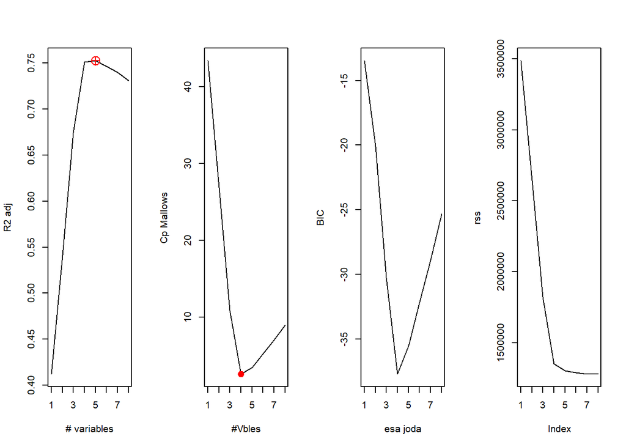

```r
# Division ventana de graficos
par(mfrow = c(1,4))

# Primer grafico
maximo_r_adj = which.max(modelofull.summary$adjr2)
plot(modelofull.summary$adjr2, type = "l", xlab = "# variables", ylab = "R2 adj")
points(maximo_r_adj, modelofull.summary$adjr2[maximo_r_adj],col = "red", cex = 2, pch =10)

# Segundo grafico
plot(modelofull.summary$cp, xlab = "#Vbles", ylab = "Cp Mallows", type = "l")
minimo_cp = which.min(modelofull.summary$cp)
points(minimo_cp, modelofull.summary$cp[minimo_cp], col ="red", cex = 2, pch =20)

# Tercer metodo graficado
plot(modelofull.summary$bic, type = "l",xlab = "esa joda", ylab = "BIC")

# Cuarto metodo
plot(modelofull.summary$rss, type = "l", ylab = "rss")
```

Ahora, vamos a comparar cuales son las variables recomendadas por cada metodo.

# Las variables en si:

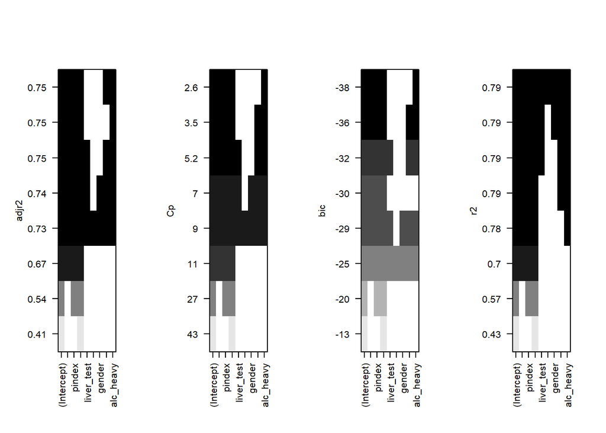

```r
par(mfrow= c(1,4))
plot(modelofull, scale = "adjr2")
plot(modelofull, scale = "Cp")
plot(modelofull, scale = "bic")
plot(modelofull, scale = "r2")
```